# iml_hw5

Michal_Raszkowski

7 05 2021

W ninejszym dokumencie przyjrzymy się ważności zmiennych w modelach trenowanych na danych ‘House Sales in King County’. Tak jak w poprzednich raportach, zbadamy dwa modele - las losowy oraz regresję liniową z regularyzacją elastic net.

### Najpierw w lesie

Zacznijmy wpierw od modelu lasu losowego. Wariancję zmiennych będziemy sprawdzać pod kątem zmiany pierwiastka błędu średniokwadratowego.

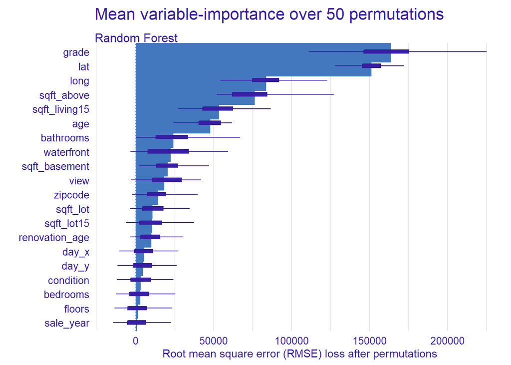

Największe znaczenie ma zmienna *grade*, zaraz po niej dwie zmienne kodujące położenie, zaś dalej informacje o powierzchni mieszkalnej i średniej powierzchni w sąsiedztwie. Są to również zmienne które najczęściej występowały w przykładach przy używaniu metod SHAP czy LIME w zeszłych pracach domowych.

### Model ten sam, zmiennych mniej

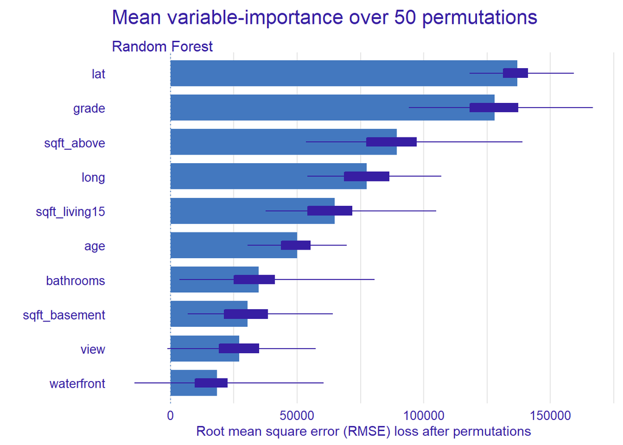

### Położenie geograficzne a kod pocztowy

Skoro nasze modele przywiązywały dużą wagę do położenia geograficznego, to zobaczmy czy zabranie zmiennych *lat* i *long* spowoduje wzrost znaczenia zmiennej *zipcode*.

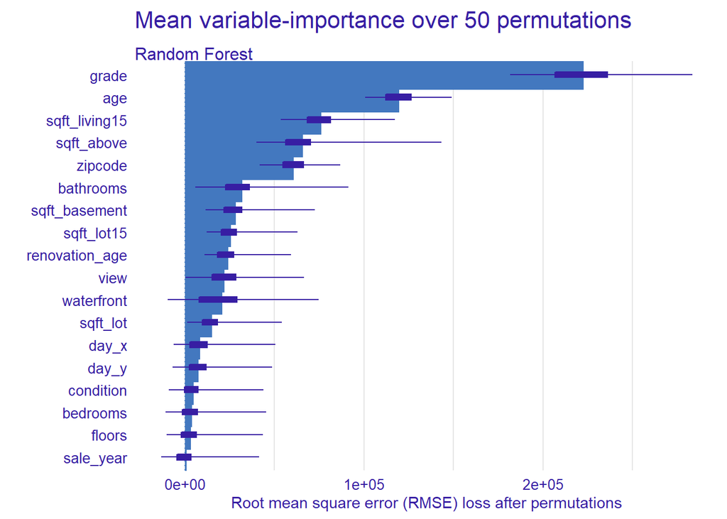

Jak widać powyżej, kod pocztowy odgrywa teraz dużo większą rolę, ale nie w tym samym stopniu co współrzędne geograficzne w pierwszej wersji. Można też zauważyć, że wzrosło znaczenie zmiennej oznaczającej średnią powierzchnię mieszkaniową w sąsiedztwie - zapewne model w ten sposób wykrywa zależności które mógł wcześniej wyczytywać bezpośrednio z położenia geograficznego. Sugeruje to, że zmienne geograficzne lepiej oddają wpływ polożenia na cenę nieruchomości niż kod pocztowy.

### Porównanie z liniowym

Na koniec przyjrzyjmy się jeszcze ważności zmiennych w modelu liniowym.

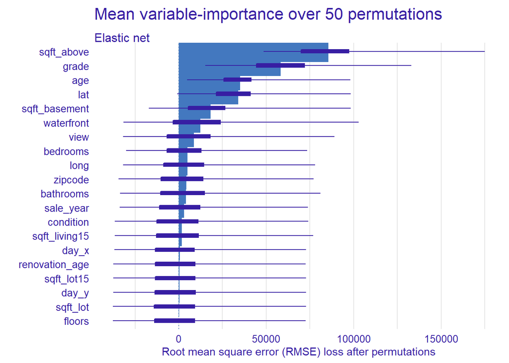